# Sam_Rogers_IP_Final_Project

Sam Rogers

12/5/2019

# Install Packages

```r
library(RODBC)
library(tidyverse)
library(philentropy)
library(factoextra)
library(RWeka)
library(partykit)
library(rpart)
library(rpart.plot)
library(caret)
library(e1071)
library(arules)
library(dplyr)
library(randomForest)
library(stringr)
library(ggplot2)
library(class)
library(png)
library(knitr)
library(plyr)
library(gbm)
```

# Load Data

In loading my data I had a lot of trouble loading from Azure SQL Server, local SQL and online csv downloads. In the end, the simplest solution was a simply copy paste or an export data from SQL source. While this isn’t the best method, I hope to solve the SQL problem when I expand my dataset to the entire state of Oklahoma and not just a singular county.

```r
Grady_Prod_Head <- read_csv("3_Grady_Prod_Headers.csv")

Grady_Compl_Head <- read_csv("Completion_Oseberg_Pull.csv")

Grady_Chem_Head <- read_csv("FracFocusCombo.csv")

Results <- read.csv("Prediction_Results.csv")

Data_Terms <- read.csv("Terms.csv")
```

### Rename Data

```r
#Rename some dataset columns
colnames(Grady_Chem_Head) <-c("pKey1", "APINumber", "OperatorName", "WellName", "Latitude", "Longitude",    "Projection", "TVD", "TotalBaseWaterVolume", "TotalBaseNonWaterVolume", "StateName",    "CountyName")


colnames(Grady_Prod_Head)[1] <-("API")
colnames(Grady_Prod_Head)[6] <-("WellName")
```

```r
#Filter early to reduce vast dataset size to Grady County for FracFocus dataset aka Grady_Chem_Head

Grady_Chem_Head <- Grady_Chem_Head %>% filter (CountyName == 'Grady')  # now 40670 observations


#Create funtion to eliminate to the right
left = function(text, num_char) {
  substr(text, 1, num_char)
}

#Create funtion to eliminate to the left
right = function(text, num_char) {
  substr(text, nchar(text) - (num_char-1), nchar(text))
}
```

```r
#Grady_Chem_Head$`APINumber` <- left(Grady_Chem_Head$`APINumber`,10)
#Grady_Prod_Head$API <- left(Grady_Prod_Head$API,10)
Grady_Compl_Head$ApiNumber <- right(Grady_Compl_Head$ApiNumber,7)
Grady_Chem_Head$APINumber <- right(Grady_Chem_Head$APINumber,7)

# Convert to Numeric from Character
Grady_Chem_Head <- Grady_Chem_Head %>% mutate(APINumber = as.character(as.numeric(APINumber)))
Grady_Prod_Head <- Grady_Prod_Head %>% mutate(API = as.character(as.numeric(API)))
Grady_Compl_Head <- Grady_Compl_Head %>%
            mutate(BHTotalLength= as.numeric(BHTotalLength))  %>%
            mutate (ApiNumber = as.character(as.numeric(ApiNumber)))
```

## Combine Datasets

```r
# Select individually important fields from datasets
OS_Comp_Full <- Grady_Compl_Head %>% select (c("ApiNumber", "FractureTreatment", "PumpingFlowing", "ChokeSize", "Legal", "BHTotalLength", "Formations"))

DI_Prod_Full <- Grady_Prod_Head %>% select (c("API", "Operator Company Name", "WellName", "Well Number","Reservoir", "Producing Status", "Drill Type","Production Type", "Spud Date", "First Month Oil","First Month Gas", "First 60 Oil", "First 60 Gas", "First 60 BOE", "Measured Depth (TD)", "Gross Perforated Interval")) %>% unite("Well Name", 'WellName':'Well Number', sep =" ", na.rm=TRUE, remove=FALSE) %>% select (-c('WellName','Well Number'))

FF_Chem_Full <- Grady_Chem_Head %>% select (c("APINumber","TVD","TotalBaseWaterVolume"))
```

```r
OS_Comp_Full <- OS_Comp_Full[!duplicated(OS_Comp_Full$ApiNumber), ]
DI_Prod_Full <- DI_Prod_Full[!duplicated(DI_Prod_Full$API), ]
FF_Chem_Full <- FF_Chem_Full[!duplicated(FF_Chem_Full$APINumber), ]  #determine if can give preference to Purpose = "Proppant" but still include if proppant not listed ***
```

```r
#left_join, smallest to largest combination
Grady <- left_join(DI_Prod_Full, OS_Comp_Full, by = c("API" = "ApiNumber"), copy=FALSE) #formations / reservoirs are long, how should I select a specific one? Perhaps make new records for each reservoir? Perhaps delete multi reservoirs
Grady <- left_join(Grady, FF_Chem_Full, by = c("API"="APINumber"), copy=FALSE)
```

## Eliminate Blank values and fields that do not add value.

```r
Clean_Grady <- Grady
Clean_Grady$'First Month Gas'[is.na(Grady$'First Month Gas')] <- 0
Clean_Grady$'First Month Oil'[is.na(Grady$'First Month Oil')] <- 0
Clean_Grady$'First Month BOE' <- Grady$'First Month Gas'/6 + Grady$'First Month Oil'
Clean_Grady$'First Month BOE' <- round(Clean_Grady$'First Month BOE')

Clean_Grady <- Clean_Grady %>% select (-c("API", "Well Name", "Producing Status", "Drill Type", "Spud Date", "ChokeSize", "Legal", "Formations", "First Month Oil", "First Month Gas", "First 60 Gas", "First 60 Oil", "First 60 BOE")) #consider using Formations or Reservoirs


#rename output aka 'First Month BOE'
colnames(Clean_Grady) <- c("Operator", "Reservoir", "Prod_Type", "MD", "Completed_Interval", "Fracture_Treatment", "Pumping_Flowing", "Lateral_Length", "TVD", "Frac_Fluid_W", "F_m_BOE")
```

## Data Exploration

```r
summary(Clean_Grady$MD)
```

```
##    Min. 1st Qu.  Median    Mean 3rd Qu.    Max.
##   10271   17308   19850   19696   22039   28585
```

```r
str(Clean_Grady$MD)
```

```
##  num [1:767] 17965 16295 19110 10271 10597 ...
```

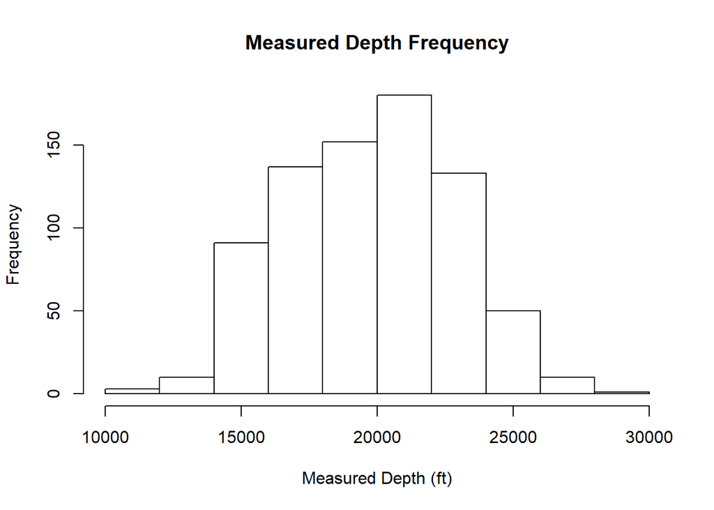

```r
hist(Clean_Grady$ MD, main= "Measured Depth Frequency", xlab = "Measured Depth (ft)")
```

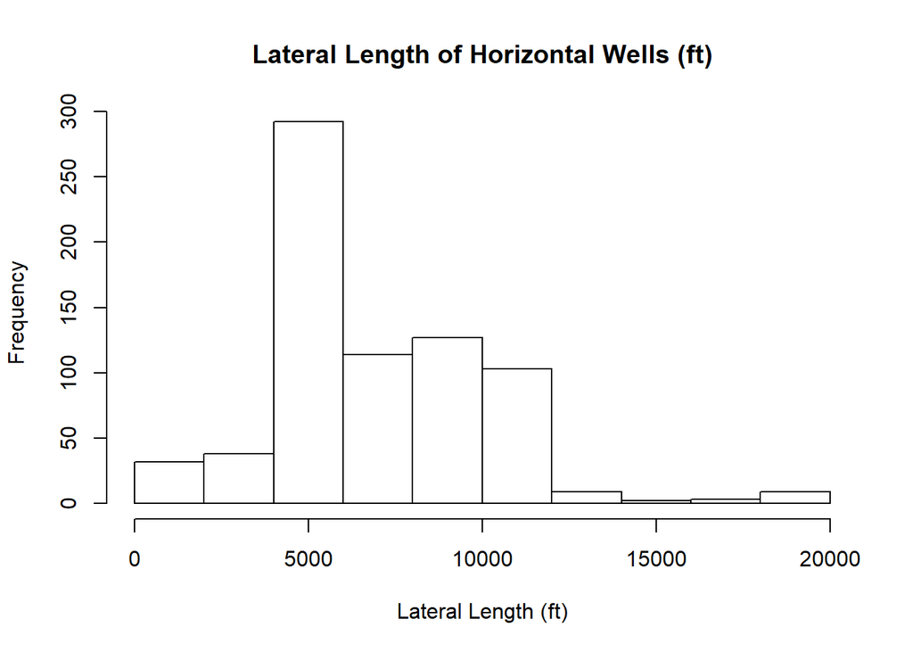

```r
hist(Clean_Grady$Lateral_Length, main= "Lateral Length of Horizontal Wells (ft)", xlab = "Lateral Length (ft)")
```

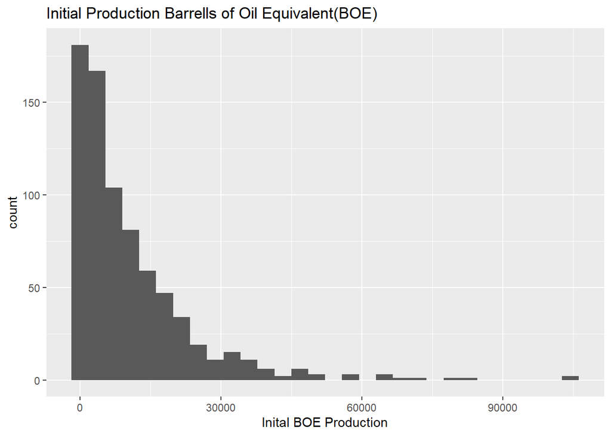

```r
ggplot(Clean_Grady, aes(x=F_m_BOE))+ geom_histogram() + ggtitle("Initial Production Barrells of Oil Equivalent(BOE)") + xlab("Inital BOE Production")
```

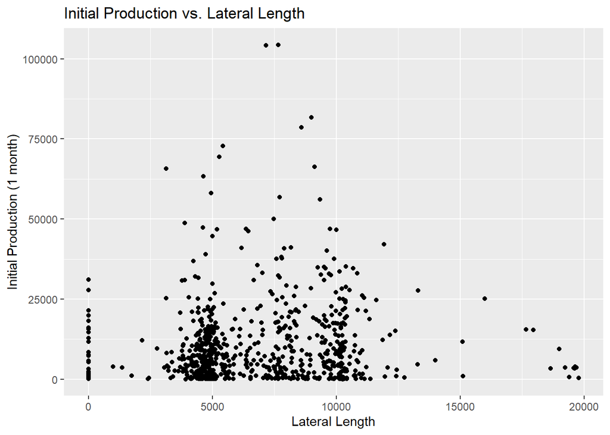

```r
ggplot(Clean_Grady, aes(x= Lateral_Length, y=F_m_BOE)) + geom_point() + ggtitle("Initial Production vs. Lateral Length") +xlab("Lateral Length") +ylab("Initial Production (1 month)")
```

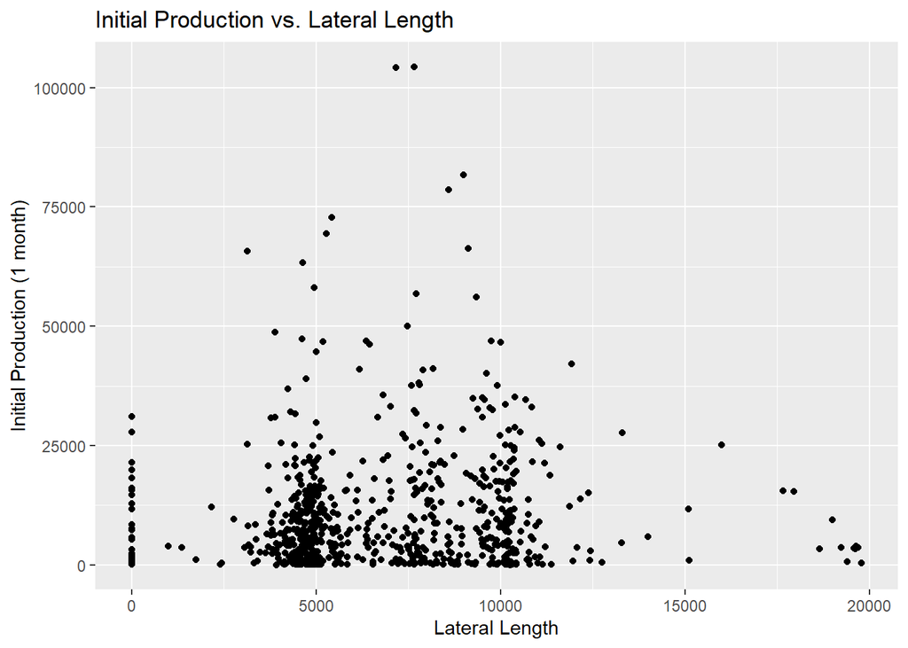

```r
ggplot(Clean_Grady, aes(x= Lateral_Length, y=F_m_BOE)) + geom_point() + ggtitle("Initial Production vs. Lateral Length") +xlab("Lateral Length") +ylab("Initial Production (1 month)")
```

## Discretize Data

BOE above 70,000 was excluded so that bins could be more uniform. In looking at the above Initial production vs. Lateral Length chart, it can be seen visually the great disparity between those outliers.

```r
Clean_Grady <- subset(Clean_Grady, F_m_BOE < 70000)

Clean_Grady <- Clean_Grady %>%
  select(-c(Fracture_Treatment)) %>% #Exclude Fracture Treatment
  drop_na() %>%
  mutate_at(vars("Lateral_Length"), funs(as.numeric)) %>%
  mutate_if(is.character, funs(as.factor)) %>% # convert categorical variables to factor
  mutate_at(vars("F_m_BOE"), funs(discretize(.,breaks=5, main= "Equal Frequency"))) %>% #discretize numeric variables
  mutate_if(is.character, funs(as.factor)) %>% # convert categorical variables to factor
  drop_na()
```

Rename Production Data Levels

Trickle Low Medium High Super Max 2 - 1,350; 1,350 - 4,670; 4,670 - 10,000; 10,000 - 18,100; 18,100 - 69,400

```r
write.csv(Clean_Grady, "Clean_Grady.csv")
Clean_Grady_Temp <- Clean_Grady
Clean_Grady <- read_csv("Clean_Grady_2.csv")


Clean_Grady$F_m_BOE <- Clean_Grady_Temp$F_m_BOE
Clean_Grady <- Clean_Grady %>%
  select(-c(Proppant, Fracture_Treatment)) %>%
  mutate_if(is.character, funs(as.factor)) %>% # convert categorical variables to factor
  drop_na()



levels(Clean_Grady$F_m_BOE) <-c("Trickle", "Low", "Medium", "High", "Super_Max")

summary(Clean_Grady$F_m_BOE)
```

```
##   Trickle       Low    Medium      High Super_Max
##       125       126       126       124       125
```

## Split Train and Test Data

```r
set.seed(25)
Train_Grady <- Clean_Grady %>% sample_frac(size = 0.8)
Test_Grady <- Clean_Grady %>% anti_join(Train_Grady)
str(Train_Grady$F_m_BOE)
```

```
##  Factor w/ 5 levels "Trickle","Low",..: 4 1 4 2 1 5 5 2 4 5 ...
```

```r
str(Test_Grady$F_m_BOE)
```

```
##  Factor w/ 5 levels "Trickle","Low",..: 4 5 5 5 1 1 3 2 3 2 ...
```

## Pre-Process Data

nzv caused the accuracy to decrease

```r
# utilize range methods in caret to remove and normalize variables

PreProc <- preProcess(Train_Grady, method = c("scale"))

Train_new <- predict(PreProc, Train_Grady)
Test_new <- predict(PreProc, Test_Grady)
```

# Data

## Data Used for Predictions

```r
head(Clean_Grady)
```

```
## # A tibble: 6 x 10
##   Operator Reservoir Prod_Type    MD Completed_Inter~ Pumping_Flowing
##   <fct>    <fct>     <fct>     <dbl>            <dbl> <fct>
## 1 ENCANA   WOODFORD  GAS       20464             4914 FLOWING
## 2 ENCANA   WOODFORD  GAS       20283             4824 FLOWING
## 3 MARATHO~ WOODFORD  GAS       18661             3696 FLOWING
## 4 ENCANA   WOODFORD  OIL       17700             4891 FLOWING
## 5 ENCANA   WOODFORD  OIL       21226            10191 FLOWING
## 6 ENCANA   MISSISSI~ OIL       21152             7272 FLOWING
## # ... with 4 more variables: Lateral_Length <dbl>, TVD <dbl>,
## #   Frac_Fluid_W <dbl>, F_m_BOE <fct>
```

# Prediction Results

## SVM

Polynomial decreased in the prediction capabilities. It could only reach about 22%. Using scale in pre-processing didn’t effect the results.

### Linear

THis makes sense as the proppant is not all one size. It’s a range of sizes and as such would have been important to include as a variable. The issue is my data sorce was extremely inconsistent in reporting the proppant size. Additionally some had to be excluded as they were clearly wrong. This being a field in which the operator could respond in a text format, there are many more opportunities for error.

```r
tune_out <- tune.svm(F_m_BOE~., data = Train_new,
                     type = "C-classification",
                     kernel = "linear",
                     cost = c(1, 5, 10),
                     gamma = c(0.001, .005))

# print out the best tuned parameters
tune_out$best.parameters$cost
```

```
## [1] 5
```

```r
tune_out$best.parameters$gamma
```

```
## [1] 0.001
```

```r
# build the optimal model
svm_optimal <- svm(F_m_BOE ~., data = Train_new,
                  type = "C-classification",
                  kernel = "linear",
                  cost = tune_out$best.parameters$cost,
                  gamma = tune_out$best.parameters$gamma)

svm_optimal_pred <- predict(svm_optimal, Test_new)

# confusion matrix
caret::confusionMatrix(data = svm_optimal_pred,
                       reference = Test_new$F_m_BOE)
```

```
## Confusion Matrix and Statistics
##
##            Reference
## Prediction  Trickle Low Medium High Super_Max
##   Trickle        14   6     10    9         3
##   Low             1   9      6    3         2
##   Medium          1   3      3    1         0
##   High            2   3      3    8         3
##   Super_Max       6   6      5    6        12
##
## Overall Statistics
##
##                Accuracy : 0.368
##                  95% CI : (0.2835, 0.4589)
##     No Information Rate : 0.216
##     P-Value [Acc > NIR] : 7.57e-05
##
##                   Kappa : 0.2176
##
##  Mcnemar's Test P-Value : 0.00325
##
## Statistics by Class:
##
##                      Class: Trickle Class: Low Class: Medium Class: High
## Sensitivity                  0.5833     0.3333        0.1111      0.2963
## Specificity                  0.7228     0.8776        0.9490      0.8878
## Pos Pred Value               0.3333     0.4286        0.3750      0.4211
## Neg Pred Value               0.8795     0.8269        0.7949      0.8208
## Prevalence                   0.1920     0.2160        0.2160      0.2160
## Detection Rate               0.1120     0.0720        0.0240      0.0640
## Detection Prevalence         0.3360     0.1680        0.0640      0.1520
## Balanced Accuracy            0.6531     0.6054        0.5300      0.5920
##                      Class: Super_Max
## Sensitivity                    0.6000
## Specificity                    0.7810
## Pos Pred Value                 0.3429
## Neg Pred Value                 0.9111
## Prevalence                     0.1600
## Detection Rate                 0.0960
## Detection Prevalence           0.2800
## Balanced Accuracy              0.6905
```

### Radial

```r
# use linear kernel
svm_radial <- svm(F_m_BOE ~., data = Train_new, type = "C-classification", kernel = "radial", cost =20, gamma= 0.1)

svm_radial
```

```
##
## Call:
## svm(formula = F_m_BOE ~ ., data = Train_new, type = "C-classification",
##     kernel = "radial", cost = 20, gamma = 0.1)
##
##
## Parameters:
##    SVM-Type:  C-classification
##  SVM-Kernel:  radial
##        cost:  20
##
## Number of Support Vectors:  484
```

```r
svm_radial_pred <- predict(svm_radial, Test_new)


str(Test_new)
```

```
## Classes 'tbl_df', 'tbl' and 'data.frame':    125 obs. of  10 variables:
##  $ Operator          : Factor w/ 20 levels "BASIN OPERATING SERVICES LLC",..: 7 5 5 5 5 5 11 5 5 5 ...
##  $ Reservoir         : Factor w/ 16 levels "CHESTER","CLEVELAND",..: 16 16 16 16 16 16 16 16 16 16 ...
##  $ Prod_Type         : Factor w/ 2 levels "GAS","OIL": 1 1 1 2 2 2 1 2 2 2 ...
##  $ MD                : num  6.54 6.4 6.09 8.1 5.6 ...
##  $ Completed_Interval: num  1.91 1.69 1.74 3.66 1.72 ...
##  $ Pumping_Flowing   : Factor w/ 5 levels "ARTIFICIAL","FLOWING",..: 2 2 2 2 2 5 2 2 2 2 ...
##  $ Lateral_Length    : num  1.86 1.69 1.73 3.55 1.72 ...
##  $ TVD               : num  2.65 2.65 2.49 2.69 2.19 ...
##  $ Frac_Fluid_W      : num  0.438 1.087 1.022 2.275 1.248 ...
##  $ F_m_BOE           : Factor w/ 5 levels "Trickle","Low",..: 4 5 5 5 1 1 3 2 3 2 ...
```

```r
# confusion matrix
caret::confusionMatrix(data = svm_radial_pred,
                       reference = Test_new$F_m_BOE)
```

```
## Confusion Matrix and Statistics
##
##            Reference
## Prediction  Trickle Low Medium High Super_Max
##   Trickle        11   9      1    7         5
##   Low             1   7      6    3         1
##   Medium          4   2      6    5         1
##   High            4   4      4    7         2
##   Super_Max       4   5     10    5        11
##
## Overall Statistics
##
##                Accuracy : 0.336
##                  95% CI : (0.254, 0.426)
##     No Information Rate : 0.216
##     P-Value [Acc > NIR] : 0.001318
##
##                   Kappa : 0.1762
##
##  Mcnemar's Test P-Value : 0.011913
##
## Statistics by Class:
##
##                      Class: Trickle Class: Low Class: Medium Class: High
## Sensitivity                  0.4583     0.2593        0.2222      0.2593
## Specificity                  0.7822     0.8878        0.8776      0.8571
## Pos Pred Value               0.3333     0.3889        0.3333      0.3333
## Neg Pred Value               0.8587     0.8131        0.8037      0.8077
## Prevalence                   0.1920     0.2160        0.2160      0.2160
## Detection Rate               0.0880     0.0560        0.0480      0.0560
## Detection Prevalence         0.2640     0.1440        0.1440      0.1680
## Balanced Accuracy            0.6203     0.5735        0.5499      0.5582
##                      Class: Super_Max
## Sensitivity                    0.5500
## Specificity                    0.7714
## Pos Pred Value                 0.3143
## Neg Pred Value                 0.9000
## Prevalence                     0.1600
## Detection Rate                 0.0880
## Detection Prevalence           0.2800
## Balanced Accuracy              0.6607
```

## Tunning

```r
tune_out <- tune.svm(F_m_BOE~., data = Train_new,
                     type = "C-classification",
                     kernel = "radial",
                     # modify the width of the decision boundary.
                     # high cost -> overfit training data. low cost -> miss subtle but important pattern
                     cost = c(1,10,20),
                     # gamma specifies how far a single training point reach, controls the kernel width
                     # small value -> larger similarity radius (points farther apart are considered similar). smoother decision boundary
                     # large value -> smaller similarity radius, more complex and contrained. less smooth boundary
                     gamma = c(.001, .01, .5))

# print out the best tuned parameters
tune_out$best.parameters$cost
```

```
## [1] 1
```

```r
tune_out$best.parameters$gamma
```

```
## [1] 0.5
```

```r
# build the optimal model
svm_optimal <- svm(F_m_BOE ~., data = Train_new,
                  type = "C-classification",
                  kernel = "radial",
                  cost = tune_out$best.parameters$cost,
                  gamma = tune_out$best.parameters$gamma)

svm_optimal_pred <- predict(svm_optimal, Test_new)

# confusion matrix
caret::confusionMatrix(data = svm_optimal_pred,
                       reference = Test_new$F_m_BOE)
```

```
## Confusion Matrix and Statistics
##
##            Reference
## Prediction  Trickle Low Medium High Super_Max
##   Trickle        11   4      1    4         5
##   Low             1   7      7    5         1
##   Medium          4   7      5    6         1
##   High            3   4      4    4         3
##   Super_Max       5   5     10    8        10
##
## Overall Statistics
##
##                Accuracy : 0.296
##                  95% CI : (0.2177, 0.3842)
##     No Information Rate : 0.216
##     P-Value [Acc > NIR] : 0.02229
##
##                   Kappa : 0.1264
##
##  Mcnemar's Test P-Value : 0.08476
##
## Statistics by Class:
##
##                      Class: Trickle Class: Low Class: Medium Class: High
## Sensitivity                  0.4583     0.2593        0.1852      0.1481
## Specificity                  0.8614     0.8571        0.8163      0.8571
## Pos Pred Value               0.4400     0.3333        0.2174      0.2222
## Neg Pred Value               0.8700     0.8077        0.7843      0.7850
## Prevalence                   0.1920     0.2160        0.2160      0.2160
## Detection Rate               0.0880     0.0560        0.0400      0.0320
## Detection Prevalence         0.2000     0.1680        0.1840      0.1440
## Balanced Accuracy            0.6599     0.5582        0.5008      0.5026
##                      Class: Super_Max
## Sensitivity                    0.5000
## Specificity                    0.7333
## Pos Pred Value                 0.2632
## Neg Pred Value                 0.8851
## Prevalence                     0.1600
## Detection Rate                 0.0800
## Detection Prevalence           0.3040
## Balanced Accuracy              0.6167
```

# Random Forest

```r
set.seed(25)
rf.model <- randomForest(F_m_BOE ~ ., data = Train_new , ntree = 500, nodesize =20)
rf.predict <- predict(rf.model, Test_new)
print(rf.cm <- confusionMatrix(rf.predict, Test_new$F_m_BOE))
```

```
## Confusion Matrix and Statistics
##
##            Reference
## Prediction  Trickle Low Medium High Super_Max
##   Trickle        11   3      4    6         4
##   Low             2   8     10    5         2
##   Medium          3   8      4    8         2
##   High            3   2      4    6         2
##   Super_Max       5   6      5    2        10
##
## Overall Statistics
##
##                Accuracy : 0.312
##                  95% CI : (0.2322, 0.401)
##     No Information Rate : 0.216
##     P-Value [Acc > NIR] : 0.007947
##
##                   Kappa : 0.1421
##
##  Mcnemar's Test P-Value : 0.669694
##
## Statistics by Class:
##
##                      Class: Trickle Class: Low Class: Medium Class: High
## Sensitivity                  0.4583     0.2963        0.1481      0.2222
## Specificity                  0.8317     0.8061        0.7857      0.8878
## Pos Pred Value               0.3929     0.2963        0.1600      0.3529
## Neg Pred Value               0.8660     0.8061        0.7700      0.8056
## Prevalence                   0.1920     0.2160        0.2160      0.2160
## Detection Rate               0.0880     0.0640        0.0320      0.0480
## Detection Prevalence         0.2240     0.2160        0.2000      0.1360
## Balanced Accuracy            0.6450     0.5512        0.4669      0.5550
##                      Class: Super_Max
## Sensitivity                    0.5000
## Specificity                    0.8286
## Pos Pred Value                 0.3571
## Neg Pred Value                 0.8969
## Prevalence                     0.1600
## Detection Rate                 0.0800
## Detection Prevalence           0.2240
## Balanced Accuracy              0.6643
```

RF 2- Shown in report. Accuracy 37.6%

```r
set.seed(25)
rf.model <- randomForest(F_m_BOE ~ ., data = Train_new , ntree = 200, nodesize =5)
rf.predict <- predict(rf.model, Test_new)
print(rf.cm <- confusionMatrix(rf.predict, Test_new$F_m_BOE))
```

```
## Confusion Matrix and Statistics
##
##            Reference
## Prediction  Trickle Low Medium High Super_Max
##   Trickle         9   2      2    6         4
##   Low             3  11      8    1         1
##   Medium          3   6      5    4         1
##   High            4   5      5   12         4
##   Super_Max       5   3      7    4        10
##
## Overall Statistics
##
##                Accuracy : 0.376
##                  95% CI : (0.291, 0.467)
##     No Information Rate : 0.216
##     P-Value [Acc > NIR] : 3.416e-05
##
##                   Kappa : 0.2214
##
##  Mcnemar's Test P-Value : 0.4877
##
## Statistics by Class:
##
##                      Class: Trickle Class: Low Class: Medium Class: High
## Sensitivity                  0.3750     0.4074        0.1852      0.4444
## Specificity                  0.8614     0.8673        0.8571      0.8163
## Pos Pred Value               0.3913     0.4583        0.2632      0.4000
## Neg Pred Value               0.8529     0.8416        0.7925      0.8421
## Prevalence                   0.1920     0.2160        0.2160      0.2160
## Detection Rate               0.0720     0.0880        0.0400      0.0960
## Detection Prevalence         0.1840     0.1920        0.1520      0.2400
## Balanced Accuracy            0.6182     0.6374        0.5212      0.6304
##                      Class: Super_Max
## Sensitivity                    0.5000
## Specificity                    0.8190
## Pos Pred Value                 0.3448
## Neg Pred Value                 0.8958
## Prevalence                     0.1600
## Detection Rate                 0.0800
## Detection Prevalence           0.2320
## Balanced Accuracy              0.6595
```

# K-Nearest Neighbor

25.6% accuracy

```r
# Remove character data as it has no levels
Wet_set <- Train_new %>%
  select (-c("Operator", "Reservoir", "Prod_Type", "Pumping_Flowing"))

#Exclude character data
Dry_set_Val <- Test_new %>%
  select (-c("Operator", "Reservoir", "Prod_Type", "Pumping_Flowing"))



label <- Wet_set$F_m_BOE  # label is a dependent variable
Wet_set <- Wet_set[,-6] # only predictor variables from train_set

#Take out F_m_BOE
Dry_set <- Dry_set_Val[,-6]
# knn model
# train - matrix or data frame of training samples
# test - matrix or data frame of test samples
# cl - factor of true classifications of training set
# k - number of neighbours considered
knn_impute <- knn(train = Wet_set, test = Dry_set, cl = label, k = 20)


# Show prediction result
caret::confusionMatrix(data = knn_impute, reference = Dry_set_Val$F_m_BOE)
```

```
## Confusion Matrix and Statistics
##
##            Reference
## Prediction  Trickle Low Medium High Super_Max
##   Trickle        11   6      4    4         5
##   Low             4   7     10    6         4
##   Medium          5   7      2    6         3
##   High            2   0      4    6         2
##   Super_Max       2   7      7    5         6
##
## Overall Statistics
##
##                Accuracy : 0.256
##                  95% CI : (0.1822, 0.3418)
##     No Information Rate : 0.216
##     P-Value [Acc > NIR] : 0.1637
##
##                   Kappa : 0.0722
##
##  Mcnemar's Test P-Value : 0.2183
##
## Statistics by Class:
##
##                      Class: Trickle Class: Low Class: Medium Class: High
## Sensitivity                  0.4583     0.2593       0.07407      0.2222
## Specificity                  0.8119     0.7551       0.78571      0.9184
## Pos Pred Value               0.3667     0.2258       0.08696      0.4286
## Neg Pred Value               0.8632     0.7872       0.75490      0.8108
## Prevalence                   0.1920     0.2160       0.21600      0.2160
## Detection Rate               0.0880     0.0560       0.01600      0.0480
## Detection Prevalence         0.2400     0.2480       0.18400      0.1120
## Balanced Accuracy            0.6351     0.5072       0.42989      0.5703
##                      Class: Super_Max
## Sensitivity                    0.3000
## Specificity                    0.8000
## Pos Pred Value                 0.2222
## Neg Pred Value                 0.8571
## Prevalence                     0.1600
## Detection Rate                 0.0480
## Detection Prevalence           0.2160
## Balanced Accuracy              0.5500
```

## Naive Bayes Model

```r
# fit a Naive Bayes model using the e1071 package
library(e1071)
set.seed(25)

nb <- naiveBayes(F_m_BOE~.,
                 data = Train_new)

pred_nb=predict(nb,
             newdata=Test_new,
             type=c("class"))

# confusion matrix
caret::confusionMatrix(data = pred_nb,
                       reference = Test_new$F_m_BOE)
```

```
## Confusion Matrix and Statistics
##
##            Reference
## Prediction  Trickle Low Medium High Super_Max
##   Trickle        13   9      8   13         7
##   Low             2   3      5    3         1
##   Medium          3   4      3    4         0
##   High            1   6      6    5         1
##   Super_Max       5   5      5    2        11
##
## Overall Statistics
##
##                Accuracy : 0.28
##                  95% CI : (0.2034, 0.3673)
##     No Information Rate : 0.216
##     P-Value [Acc > NIR] : 0.054688
##
##                   Kappa : 0.1069
##
##  Mcnemar's Test P-Value : 0.002743
##
## Statistics by Class:
##
##                      Class: Trickle Class: Low Class: Medium Class: High
## Sensitivity                  0.5417     0.1111        0.1111      0.1852
## Specificity                  0.6337     0.8878        0.8878      0.8571
## Pos Pred Value               0.2600     0.2143        0.2143      0.2632
## Neg Pred Value               0.8533     0.7838        0.7838      0.7925
## Prevalence                   0.1920     0.2160        0.2160      0.2160
## Detection Rate               0.1040     0.0240        0.0240      0.0400
## Detection Prevalence         0.4000     0.1120        0.1120      0.1520
## Balanced Accuracy            0.5877     0.4994        0.4994      0.5212
##                      Class: Super_Max
## Sensitivity                    0.5500
## Specificity                    0.8381
## Pos Pred Value                 0.3929
## Neg Pred Value                 0.9072
## Prevalence                     0.1600
## Detection Rate                 0.0880
## Detection Prevalence           0.2240
## Balanced Accuracy              0.6940
```

## Boosted Tree model

```r
# fit a boosted model
set.seed(25)

# use 10-fold cross validation
train_control <- trainControl(method = "cv",
                              number = 15)


gbm_model <- train(F_m_BOE~.,
                 data = Train_new,
                 method = "gbm",
                 trControl = train_control)
```

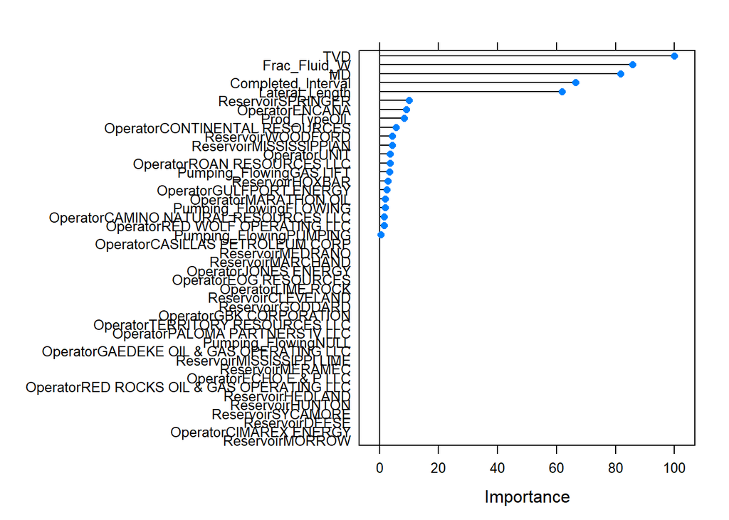

```r
# plot variable important
plot(varImp(gbm_model))
```

```r
# make prediction on the test set
gbm_model_prediction <- predict(gbm_model,
                            newdata = Test_new[,-10],
                            type="raw")

# confusion matrix
caret::confusionMatrix(data = gbm_model_prediction,
                       reference = Test_new$F_m_BOE)
```

```
## Confusion Matrix and Statistics
##
##            Reference
## Prediction  Trickle Low Medium High Super_Max
##   Trickle        11   5      4    6         3
##   Low             2   8      5    1         0
##   Medium          2   4      4    2         3
##   High            4   5      5   15         4
##   Super_Max       5   5      9    3        10
##
## Overall Statistics
##
##                Accuracy : 0.384
##                  95% CI : (0.2984, 0.4752)
##     No Information Rate : 0.216
##     P-Value [Acc > NIR] : 1.493e-05
##
##                   Kappa : 0.2337
##
##  Mcnemar's Test P-Value : 0.1299
##
## Statistics by Class:
##
##                      Class: Trickle Class: Low Class: Medium Class: High
## Sensitivity                  0.4583     0.2963        0.1481      0.5556
## Specificity                  0.8218     0.9184        0.8878      0.8163
## Pos Pred Value               0.3793     0.5000        0.2667      0.4545
## Neg Pred Value               0.8646     0.8257        0.7909      0.8696
## Prevalence                   0.1920     0.2160        0.2160      0.2160
## Detection Rate               0.0880     0.0640        0.0320      0.1200
## Detection Prevalence         0.2320     0.1280        0.1200      0.2640
## Balanced Accuracy            0.6401     0.6073        0.5180      0.6859
##                      Class: Super_Max
## Sensitivity                    0.5000
## Specificity                    0.7905
## Pos Pred Value                 0.3125
## Neg Pred Value                 0.8925
## Prevalence                     0.1600
## Detection Rate                 0.0800
## Detection Prevalence           0.2560
## Balanced Accuracy              0.6452
```

# Areas which did not work

## Modeling using RPart Pre-Pruning

```r
#Train_Grady_Prune <- Train_Grady %>% select(c("Operator", "Reservoir", "Prod_Type", "Completed_Interval", "Pumping_Flowing", "Frac_Fluid_W", "F_m_BOE"))
#Test_Grady_Prune <- Test_Grady %>% select(c("Operator", "Reservoir", "Prod_Type", "Completed_Interval", "Pumping_Flowing", "Frac_Fluid_W", "F_m_BOE"))

#rebuild prepruned tree
# Grady_Rpart <- rpart(Operator~.,
#               data=Train_Grady_Prune,
#               method= "class")

# plot the tree
# rpart.plot(Grady_Rpart, box.palette="RdBu", shadow.col="gray", nn=TRUE)
```

## Prediction using RPart

```r
# make prediction
### rpart_prediction <- predict(Grady_Rpart, newdata = Test_Grady %>% select(-F_m_BOE),
###                            type="class")


### caret::confusionMatrix(data = rpart_prediction,
###                       reference = Test_Grady$F_m_BOE)
```

I tried making Kmeans and decision trees, however recieved errors relating to the nature of my data being too large on account that it’s in continous variables. They’re not true factors and therefore not suitable for these types of analysis.

## Predictions which didn’t work

## Extracting Proppant Data

Fracture Treatment has many treatments listed in a string. Proppant has many brands as well, but a commonality is the use of “POUNDS” following the value of proppant. In the Oil and Gas industry, MM reffers to 1000*1000 and M to 1000. So for example 2.3 MM POUNDS OF proppant is 2,300,000